# Activity Monitoring

Duc

Sunday, January 10, 2016

Set the default of echo to be true throughout the document:

```r
library(knitr)
opts_chunk$set(echo = TRUE)
```

### Load and check structure of data

```r
ds <- read.csv("activity.csv")
str(ds)
```

```
## 'data.frame':    17568 obs. of  3 variables:
##  $ steps   : int  NA NA NA NA NA NA NA NA NA NA ...
##  $ date    : Factor w/ 61 levels "2012-10-01","2012-10-02",..: 1 1 1 1 1 1 1 1 1 1 ...
##  $ interval: int  0 5 10 15 20 25 30 35 40 45 ...
```

### What is mean total number of steps taken per day?

1. Calculate the total number of steps taken per day: we can do this by `tapply` function

```r
res1 <- tapply(ds$steps, ds$date, sum)
```

2. Histogram of the total number of steps taken each day

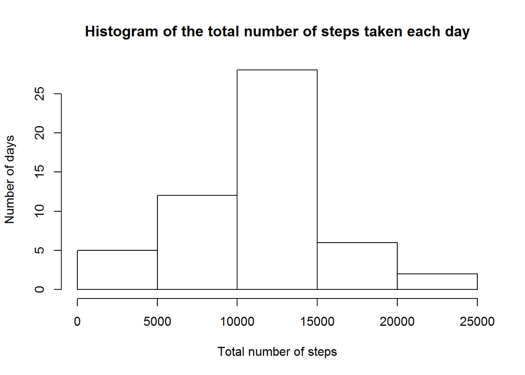

```r
hist(res1, xlab = "Total number of steps", ylab = "Number of days",
     main = "Histogram of the total number of steps taken each day")
```

3. Mean and median of the total number of steps taken per day (ignoring NAs):

```r
mean(res1, na.rm = T)
```

```
## [1] 10766
```

```r
median(res1, na.rm = T)
```

```
## [1] 10765
```

### What is the average daily activity pattern?

1. Time series plot of the average number of steps taken in each 5-minute interval, where we average over all days.
2. compute the average for each 5-minute interval

```r
require(plyr)
intervals <- unique(ds$interval)
daily.ds <- ldply(intervals, function(ii) {
  avg.steps <- with(ds, mean(steps[interval == ii], na.rm = T))
  data.frame("interval" = ii, "avg.steps" = avg.steps)
})
```

2. plot the time series

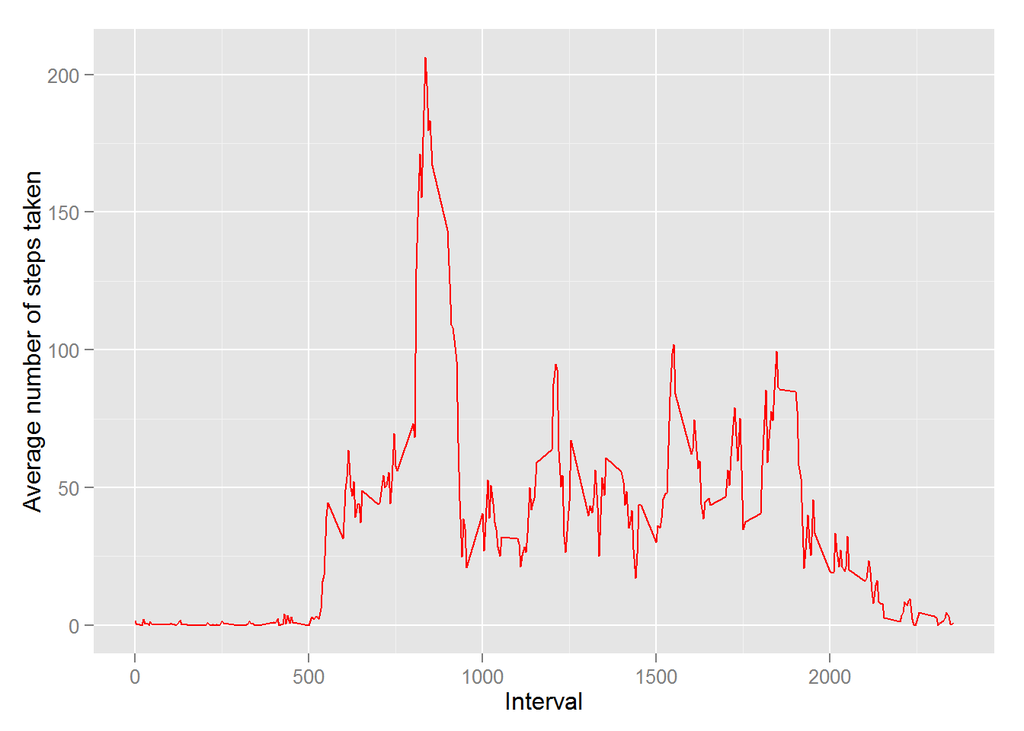

```r
require(ggplot2)
pp <- ggplot(data = daily.ds, aes(x = interval, y = avg.steps)) + geom_line(colour = "red")
pp <- pp + xlab("Interval") + ylab("Average number of steps taken")
pp
```

3. Careful observation of the intervals (their ids actually) show that the ids >= 100 are actually not integers!! They actually have the form hhmm, for example 105 is 1 hour, 5 mins. Thus we need to parse the intervals using `lubridate` library.

```r
require(lubridate)
daily.ds <- transform(daily.ds, parse.interval = hm(interval/100))
```

4. We found that the interval containing the maximum number of steps is 8:35AM. This is reasonable since that is the time we go to work.

```r
with(daily.ds, parse.interval[which.max(avg.steps)])
```

```
## [1] "8H 35M 0S"
```

### Imputing missing values

1. The total number of missing values in the dataset is:

```r
sum(is.na(ds$steps))
```

```
## [1] 2304
```

2. We will impute missing values by the mean of the corresponding interval

```r
nas <- which(is.na(ds$steps))
full.steps <- numeric(nrow(ds))
full.steps[-nas] <- ds$steps[-nas]
full.steps[nas] <- sapply(nas, function(rr) {
  with(daily.ds, avg.steps[interval == ds$interval[rr]])
})
full.ds <- data.frame("steps" = full.steps, "date" = ymd(ds$date), "interval" = ds$interval)
```

3. After imputing missing values, the new histogram of the total number of steps taken each day:

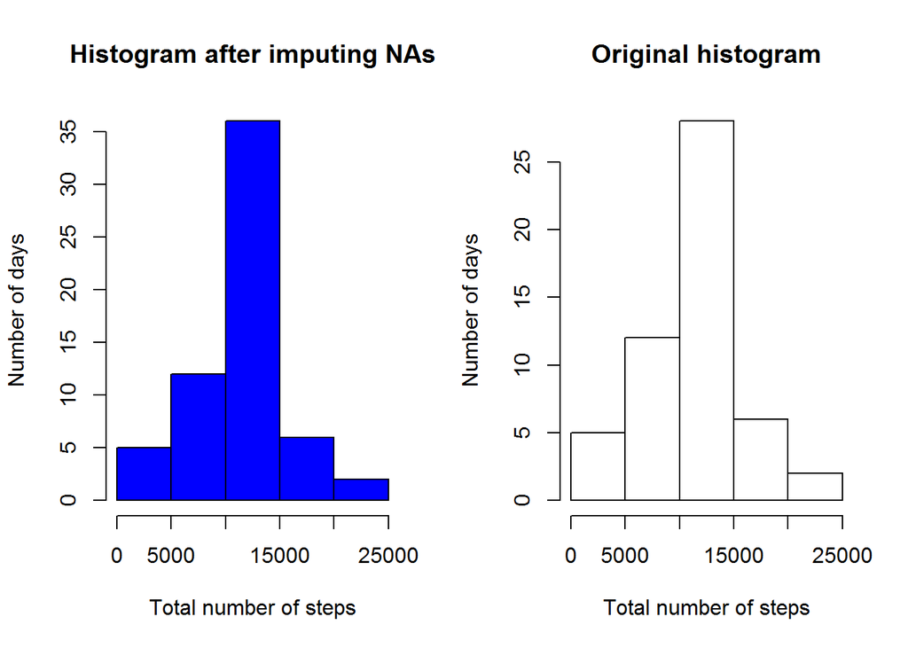

```r
steps.per.day <- tapply(full.ds$steps, full.ds$date, sum)
par(mfrow = c(1, 2))
hist(steps.per.day, xlab = "Total number of steps", ylab = "Number of days",
     main = "Histogram after imputing NAs", col = "blue")
hist(res1, xlab = "Total number of steps", ylab = "Number of days",
     main = "Original histogram")
```

1. Mean total number of steps:

```r
# before imputing missing values
mean(res1, na.rm = T)
```

```
## [1] 10766
```

```r
# after imputing missing values
mean(steps.per.day)
```

```
## [1] 10766
```

The `mean` stays the same.

2. Median total number of steps:

```r
# before imputing missing values
median(res1, na.rm = T)
```

```
## [1] 10765
```

```r
# after imputing missing values
median(steps.per.day)
```

```
## [1] 10766
```

The `median` is slightly increase.

### Are there differences in activity patterns between weekdays and weekends?

1. Create indicators for weekdays and weekends:

```r
full.ds <- transform(full.ds, weekday = weekdays(date))
full.ds <- transform(full.ds, type = ifelse(weekday %in% c("Saturday", "Sunday"), "weekend", "weekday"))
```

```r
require(dplyr)
```

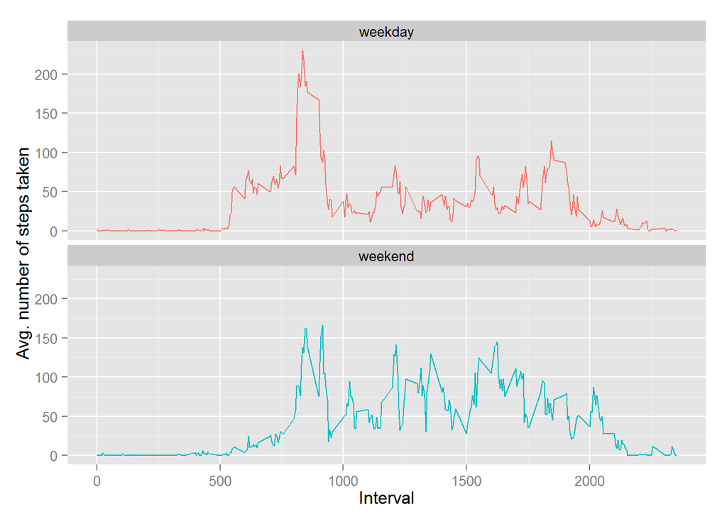

```r
interval_full <- full.ds %>% group_by(interval, type) %>% summarise(avg.steps = mean(steps))
p2 <- ggplot(data = interval_full, aes(x = interval, y = avg.steps, colour = type)) + geom_line() +
    facet_wrap(~ type, ncol = 1, nrow=2) + theme(legend.position="none")

p2 <- p2 + xlab("Interval") + ylab("Avg. number of steps taken")
p2
```

From the two plots, we can see that the test subject is more active earlier in the day during weekdays compared to weekends. Possible explanation is that he needs to wake up to prepare for working. Also, the peak of activity on weekends is later than weekdays, which shows that the subject sleeps in on weekends.